# ABAxCOV

Cassie Gonzales

4/2/2022

## Load Data

```r
library(here)
```

```r
library(sjPlot)
library(tidyverse)
library(haven)
library(lme4)
library(lmerTest)
library(MuMIn)
library(sjPlot)
library(emmeans)
library(modelsummary)
library(glmmTMB)
library(interactions)
library(rstatix)
library(r2mlm)
library(broom.mixed)
theme_set(theme_bw())
```

```r
abacov <- read_sav(here("data_files", "ABAXCOV 2022","Abacov3_long.sav"))
```

```r
rmarkdown::paged_table(abacov)
```

| ID | PIN | Site | Sex | Race | RaceTri | Age | PrimPay3 | PrimPay25 | Hours | Tele | Time | Season | Phase | Phase1 | Phase2 | Phase3 | dumPhase1 | dumPhase2 | dumPhase3 |
| --- | --- | --- | --- | --- | --- | --- | --- | --- | --- | --- | --- | --- | --- | --- | --- | --- | --- | --- | --- |
| 1 | 141659 | 0 | 0 | 1 | 1 | 9 | 0 | 0 | 53.000000 | 0 | 0 | 0 | 1 | 0 | 0 | 0 | 1 | 0 | 0 |
| 1 | 141659 | 0 | 0 | 1 | 1 | 9 | 0 | 0 | 28.500000 | 0 | 1 | 0 | 1 | 1 | 0 | 0 | 1 | 0 | 0 |
| 1 | 141659 | 0 | 0 | 1 | 1 | 9 | 0 | 0 | 31.750000 | 0 | 2 | 0 | 1 | 2 | 0 | 0 | 1 | 0 | 0 |
| 1 | 141659 | 0 | 0 | 1 | 1 | 9 | 0 | 0 | 45.283330 | 0 | 3 | 1 | 1 | 3 | 0 | 0 | 1 | 0 | 0 |
| 1 | 141659 | 0 | 0 | 1 | 1 | 9 | 0 | 0 | 150.583300 | 0 | 4 | 1 | 1 | 4 | 0 | 0 | 1 | 0 | 0 |
| 1 | 141659 | 0 | 0 | 1 | 1 | 9 | 0 | 0 | 94.300000 | 0 | 5 | 1 | 1 | 5 | 0 | 0 | 1 | 0 | 0 |
| 1 | 141659 | 0 | 0 | 1 | 1 | 9 | 0 | 0 | 37.666670 | 0 | 6 | 0 | 1 | 6 | 0 | 0 | 1 | 0 | 0 |
| 1 | 141659 | 0 | 0 | 1 | 1 | 9 | 0 | 0 | 36.700000 | 0 | 7 | 0 | 1 | 7 | 0 | 0 | 1 | 0 | 0 |
| 1 | 141659 | 0 | 0 | 1 | 1 | 9 | 0 | 0 | 32.750000 | 0 | 8 | 1 | 1 | 8 | 0 | 0 | 1 | 0 | 0 |
| 1 | 141659 | 0 | 0 | 1 | 1 | 9 | 0 | 0 | 31.416660 | 0 | 9 | 1 | 1 | 9 | 0 | 0 | 1 | 0 | 0 |

[output cut: 7190 more lines]

```r
abacov$Site <- as.factor(abacov$Site)
abacov$Sex <- as.factor(abacov$Sex)
abacov$Race <- as.factor(abacov$Race)
abacov$RaceTri <- as.factor(abacov$RaceTri)
abacov$Age <- as.numeric(abacov$Age)
abacov$PrimPay3 <- as.factor(abacov$PrimPay3)
abacov$PrimPay25 <- as.factor(abacov$PrimPay25)
abacov$Tele <- as.factor(abacov$Tele)
```

## Explore Data

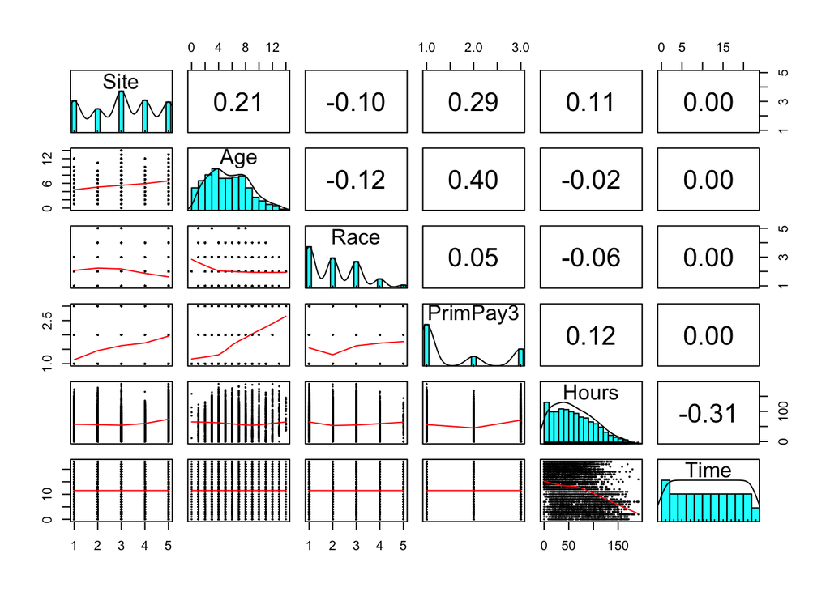

```r
abacov %>%
    select(Site, Age, Race, PrimPay3, Hours, Time) %>%
    psych::pairs.panels(ellipses = FALSE, cex = 0.2, cex.cor = 1)
```

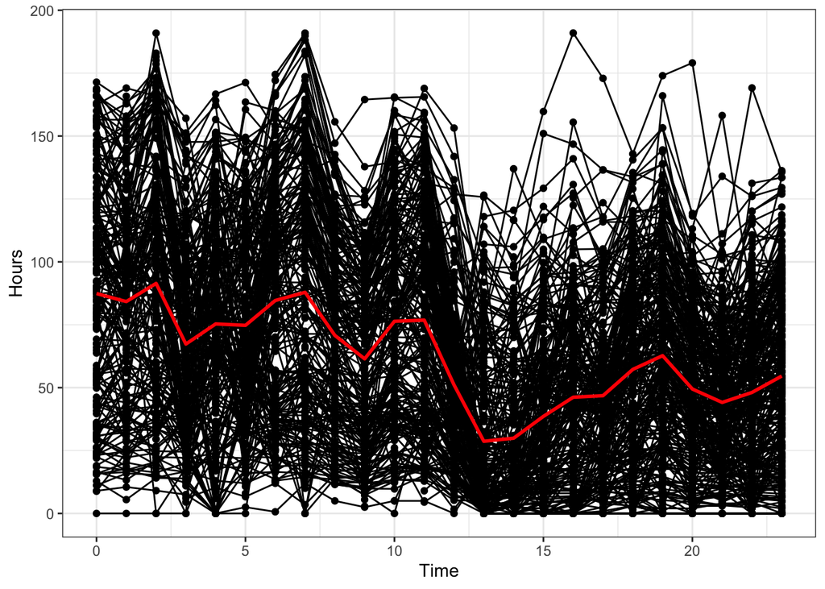

```r
p1 <- ggplot(abacov, aes(x = Time, y = Hours)) +
  geom_point() +
  geom_line(aes(group = ID)) +  # add lines to connect the data for each person
  # add a mean trajectory
  stat_summary(fun = "mean", col = "red", size = 1, geom = "line")
p1
```

```r
abacov %>%
  get_summary_stats(Hours, type = "mean_sd")
```

```
## # A tibble: 1 × 4
##   variable     n  mean    sd
##   <chr>    <dbl> <dbl> <dbl>
## 1 Hours     5356  60.9  41.6
```

```r
abacov %>%
  group_by(PrimPay3) %>%
  get_summary_stats(Hours, type = "mean_sd")
```

```
## # A tibble: 3 × 5
##   PrimPay3 variable     n  mean    sd
##   <fct>    <chr>    <dbl> <dbl> <dbl>
## 1 0        Hours     3118  58.6  39.1
## 2 1        Hours      727  48.1  36.4
## 3 2        Hours     1511  72.0  46.3
```

```r
abacov %>%
  group_by(RaceTri) %>%
  get_summary_stats(Hours, type = "mean_sd")
```

```
## # A tibble: 4 × 5
##   RaceTri variable     n  mean    sd
##   <fct>   <chr>    <dbl> <dbl> <dbl>
## 1 0       Hours     1706  66.4  42.2
## 2 1       Hours     1185  55.8  38.8
## 3 2       Hours     1509  59.3  42.2
## 4 <NA>    Hours      956  60.0  41.9
```

```r
abacov %>%
  group_by(Phase) %>%
  get_summary_stats(Hours, type = "mean_sd")
```

```
## # A tibble: 3 × 5
##   Phase variable     n  mean    sd
##   <dbl> <chr>    <dbl> <dbl> <dbl>
## 1     1 Hours     2420  77.9  43.1
## 2     2 Hours      666  36.7  33.1
## 3     3 Hours     2270  50.0  34.4
```

```r
abacov %>%
  group_by(Phase, PrimPay3) %>%
  get_summary_stats(Hours, type = "mean_sd")
```

```
## # A tibble: 9 × 6
##   PrimPay3 Phase variable     n  mean    sd
##   <fct>    <dbl> <chr>    <dbl> <dbl> <dbl>
## 1 0            1 Hours     1381  70.1  40.2
## 2 1            1 Hours      315  62.1  41.0
## 3 2            1 Hours      724  99.7  41.2
## 4 0            2 Hours      385  38.7  33.4
## 5 1            2 Hours       89  31.3  29.7
## 6 2            2 Hours      192  35.0  33.9
## 7 0            3 Hours     1352  52.5  35.6
## 8 1            3 Hours      323  39.0  27.4
## 9 2            3 Hours      595  50.2  34.0
```

```r
abacov %>%
  group_by(Phase, RaceTri) %>%
  get_summary_stats(Hours, type = "mean_sd")
```

```
## # A tibble: 12 × 6
##    RaceTri Phase variable     n  mean    sd
##    <fct>   <dbl> <chr>    <dbl> <dbl> <dbl>
##  1 0           1 Hours      808  83.7  41.6
##  2 1           1 Hours      547  68.9  43.0
##  3 2           1 Hours      696  78.2  44.2
##  4 <NA>        1 Hours      369  78.3  42.4
##  5 0           2 Hours      207  37.7  34.8
##  6 1           2 Hours      146  39.3  32.9
##  7 2           2 Hours      191  34.3  30.4
##  8 <NA>        2 Hours      122  35.5  34.8
##  9 0           3 Hours      691  54.9  36.0
## 10 1           3 Hours      492  46.1  30.0
## 11 2           3 Hours      622  46.0  33.0
## 12 <NA>        3 Hours      465  52.0  37.1
```

## Unconditional Model

```r
ran_int <- lmer(Hours ~ 1 + (1 | ID), data = abacov)

summary(ran_int)
```

```
## Linear mixed model fit by REML. t-tests use Satterthwaite's method [
## lmerModLmerTest]
## Formula: Hours ~ 1 + (1 | ID)
##    Data: abacov
##
## REML criterion at convergence: 53289.3
##
## Scaled residuals:
##     Min      1Q  Median      3Q     Max
## -3.0089 -0.6001 -0.0510  0.5955  3.8479
##
## Random effects:
##  Groups   Name        Variance Std.Dev.
##  ID       (Intercept)  620.7   24.91
##  Residual             1085.5   32.95
## Number of obs: 5356, groups:  ID, 277
##
## Fixed effects:
##             Estimate Std. Error      df t value Pr(>|t|)
## (Intercept)   59.382      1.594 277.586   37.25   <2e-16 ***
## ---
## Signif. codes:  0 '***' 0.001 '**' 0.01 '*' 0.05 '.' 0.1 ' ' 1
```

fixed effect: Y00 is 59.38. The estimated grand mean of hours for all participants is 59.38

random effect: Uij = 620.7 is the deviation between jth individual and the grand mean. Eij = 1085.5 this is the deviation of the ith timepoint from the mean hours received by a child.

### ICC calculation

```r
620.7/(620.7 + 1085.5)
```

```
## [1] 0.3637909
```

The proportation of the variance in hours of therapy utillization that is due to between participant differences is .364.

### Design Effect

Design effect = 1 + (average cluster size - 1) x ICC

```r
mean(table(abacov$ID))
```

```
## [1] 24
```

mean cluster size = 24

```r
1 + 23*.3638
```

```
## [1] 9.3674
```

design effect = 9.3674

## Hypothesis Testing

```r
m_phase <- glmmTMB(Hours ~ Phase1 + Phase2 + Phase3 + (Phase1 + Phase2 + Phase3 | ID), data = abacov, REML = TRUE)
summary(m_phase)
```

```
##  Family: gaussian  ( identity )
## Formula:
## Hours ~ Phase1 + Phase2 + Phase3 + (Phase1 + Phase2 + Phase3 |      ID)
## Data: abacov
##
##      AIC      BIC   logLik deviance df.resid
##  50247.7  50346.5 -25108.8  50217.7     5345
##
## Random effects:
##
## Conditional model:
##  Groups   Name        Variance Std.Dev. Corr
##  ID       (Intercept) 1439.70  37.943
##           Phase1        10.50   3.240   -0.49
##           Phase2       228.24  15.107   -0.33 -0.43
##           Phase3        16.88   4.108    0.22  0.15 -0.66
##  Residual              473.40  21.758
## Number of obs: 5356, groups:  ID, 277
##
## Dispersion estimate for gaussian family (sigma^2):  473
##
## Conditional model:
##             Estimate Std. Error z value Pr(>|z|)
## (Intercept)  83.3374     2.7384  30.433  < 2e-16 ***
## Phase1       -1.4452     0.2587  -5.585 2.33e-08 ***
## Phase2      -10.8176     1.0628 -10.179  < 2e-16 ***
## Phase3        2.4010     0.2966   8.095 5.74e-16 ***
## ---
## Signif. codes:  0 '***' 0.001 '**' 0.01 '*' 0.05 '.' 0.1 ' ' 1
```

During phase 1, hours of therapy significantly decreased by an average of 1.45 hours per month During phase 2, hours of therapy significantly decreased by an average of 10.82 hours per month During phase 3, hours of therapy significantly increased by an average of 2.4 hours per month

```r
m_season <- glmmTMB(Hours ~ Phase1 + Phase2 + Phase3 + Season + (Phase1 + Phase2 + Phase3 | ID), data = abacov, REML = TRUE)
summary(m_season)
```

```
##  Family: gaussian  ( identity )
## Formula:
## Hours ~ Phase1 + Phase2 + Phase3 + Season + (Phase1 + Phase2 +
##     Phase3 | ID)
## Data: abacov
##
##      AIC      BIC   logLik deviance df.resid
##  50161.7  50267.1 -25064.9  50129.7     5345
##
## Random effects:
##
## Conditional model:
##  Groups   Name        Variance Std.Dev. Corr
##  ID       (Intercept) 1438.12  37.923
##           Phase1        10.51   3.241   -0.48
##           Phase2       231.64  15.220   -0.33 -0.43
##           Phase3        17.08   4.133    0.22  0.16 -0.66
##  Residual              464.06  21.542
## Number of obs: 5356, groups:  ID, 277
##
## Dispersion estimate for gaussian family (sigma^2):  464
##
## Conditional model:
##             Estimate Std. Error z value Pr(>|z|)
## (Intercept)  86.0142     2.7496  31.282  < 2e-16 ***
## Phase1       -1.5434     0.2584  -5.972 2.34e-09 ***
## Phase2      -10.2668     1.0698  -9.597  < 2e-16 ***
## Phase3        2.2557     0.2976   7.580 3.44e-14 ***
## Season       -5.6817     0.6057  -9.380  < 2e-16 ***
## ---
## Signif. codes:  0 '***' 0.001 '**' 0.01 '*' 0.05 '.' 0.1 ' ' 1
```

Clients recieved an average of 5.68 less hours per month during “off months” compared to “on months”

```r
m_covar <- glmmTMB(Hours ~ Phase1 + Phase2 + Phase3 + Season + Age + Site + (Phase1 + Phase2 + Phase3 | ID), data = abacov, REML = TRUE)
summary(m_covar)
```

```
##  Family: gaussian  ( identity )
## Formula:
## Hours ~ Phase1 + Phase2 + Phase3 + Season + Age + Site + (Phase1 +
##     Phase2 + Phase3 | ID)
## Data: abacov
##
##      AIC      BIC   logLik deviance df.resid
##  48671.0  48808.7 -24314.5  48629.0     5196
##
## Random effects:
##
## Conditional model:
##  Groups   Name        Variance Std.Dev. Corr
##  ID       (Intercept) 1339.44  36.598
##           Phase1        10.82   3.290   -0.53
##           Phase2       221.97  14.899   -0.24 -0.48
##           Phase3        14.69   3.833    0.13  0.19 -0.65
##  Residual              461.90  21.492
## Number of obs: 5207, groups:  ID, 268
##
## Dispersion estimate for gaussian family (sigma^2):  462
##
## Conditional model:
##             Estimate Std. Error z value Pr(>|z|)
## (Intercept)  91.6252     4.8348  18.951  < 2e-16 ***
## Phase1       -1.5454     0.2646  -5.840 5.22e-09 ***
## Phase2      -10.5694     1.0673  -9.903  < 2e-16 ***
## Phase3        2.4208     0.2872   8.428  < 2e-16 ***
## Season       -5.8784     0.6128  -9.593  < 2e-16 ***
## Age          -1.2441     0.5242  -2.373 0.017633 *
## Site1         0.3842     5.1003   0.075 0.939954
## Site2         1.2683     4.5286   0.280 0.779422
## Site3        -6.3438     4.6235  -1.372 0.170038
## Site4        17.6898     5.0050   3.534 0.000409 ***
## ---
## Signif. codes:  0 '***' 0.001 '**' 0.01 '*' 0.05 '.' 0.1 ' ' 1
```

FINAL MAIN EFFECT MODEL

```r
m_covar5 <- glmmTMB(Hours ~ Phase1 + Phase2 + Phase3 + Season + Age + Site + (Phase1 + Phase2 + Phase3 | ID), data = abacov, REML = TRUE)
summary(m_covar5)
```

```
##  Family: gaussian  ( identity )
## Formula:
## Hours ~ Phase1 + Phase2 + Phase3 + Season + Age + Site + (Phase1 +
##     Phase2 + Phase3 | ID)
## Data: abacov
##
##      AIC      BIC   logLik deviance df.resid
##  48671.0  48808.7 -24314.5  48629.0     5196
##
## Random effects:
##
## Conditional model:
##  Groups   Name        Variance Std.Dev. Corr
##  ID       (Intercept) 1339.44  36.598
##           Phase1        10.82   3.290   -0.53
##           Phase2       221.97  14.899   -0.24 -0.48
##           Phase3        14.69   3.833    0.13  0.19 -0.65
##  Residual              461.90  21.492
## Number of obs: 5207, groups:  ID, 268
##
## Dispersion estimate for gaussian family (sigma^2):  462
##
## Conditional model:
##             Estimate Std. Error z value Pr(>|z|)
## (Intercept)  91.6252     4.8348  18.951  < 2e-16 ***
## Phase1       -1.5454     0.2646  -5.840 5.22e-09 ***
## Phase2      -10.5694     1.0673  -9.903  < 2e-16 ***
## Phase3        2.4208     0.2872   8.428  < 2e-16 ***
## Season       -5.8784     0.6128  -9.593  < 2e-16 ***
## Age          -1.2441     0.5242  -2.373 0.017633 *
## Site1         0.3842     5.1003   0.075 0.939954
## Site2         1.2683     4.5286   0.280 0.779422
## Site3        -6.3438     4.6235  -1.372 0.170038
## Site4        17.6898     5.0050   3.534 0.000409 ***
## ---
## Signif. codes:  0 '***' 0.001 '**' 0.01 '*' 0.05 '.' 0.1 ' ' 1
```

### Model 2

```r
m_race <- glmmTMB(Hours ~ (Phase1 + Phase2 + Phase3) * RaceTri + Season + Age + Site + (Phase1 + Phase2 + Phase3 | ID), data = abacov, REML = TRUE)
summary(m_race)
```

```
##  Family: gaussian  ( identity )
## Formula:
## Hours ~ (Phase1 + Phase2 + Phase3) * RaceTri + Season + Age +
##     Site + (Phase1 + Phase2 + Phase3 | ID)
## Data: abacov
##
##      AIC      BIC   logLik deviance df.resid
##  41027.5  41212.8 -20484.7  40969.5     4388
##
## Random effects:
##
## Conditional model:
##  Groups   Name        Variance Std.Dev. Corr
##  ID       (Intercept) 1393.15  37.325
##           Phase1        12.08   3.475   -0.55
##           Phase2       206.41  14.367   -0.20 -0.49
##           Phase3        13.06   3.614    0.08  0.18 -0.60
##  Residual              453.49  21.295
## Number of obs: 4399, groups:  ID, 215
##
## Dispersion estimate for gaussian family (sigma^2):  453
##
## Conditional model:
##                 Estimate Std. Error z value Pr(>|z|)
## (Intercept)      91.9743     6.6957  13.736  < 2e-16 ***
## Phase1           -1.4737     0.4708  -3.130 0.001749 **
## Phase2          -11.7087     1.8144  -6.453 1.10e-10 ***
## Phase3            2.8145     0.4884   5.763 8.28e-09 ***
## RaceTri1         -4.8142     7.5311  -0.639 0.522666
## RaceTri2         -4.5570     7.0332  -0.648 0.517029
## Season           -5.3734     0.6594  -8.149 3.67e-16 ***
## Age              -1.0730     0.5914  -1.815 0.069599 .
## Site1             3.2005     5.5991   0.572 0.567585
## Site2             4.0640     4.9749   0.817 0.413985
## Site3            -5.7269     5.2615  -1.088 0.276401
## Site4            21.1894     5.5681   3.805 0.000142 ***
## Phase1:RaceTri1  -0.6016     0.7404  -0.813 0.416462
## Phase1:RaceTri2   0.1612     0.6902   0.234 0.815330
## Phase2:RaceTri1   5.4776     2.8287   1.936 0.052811 .
## Phase2:RaceTri2  -1.0099     2.6437  -0.382 0.702475
## Phase3:RaceTri1  -1.7265     0.7573  -2.280 0.022613 *
## Phase3:RaceTri2  -0.2333     0.7087  -0.329 0.742035
## ---
## Signif. codes:  0 '***' 0.001 '**' 0.01 '*' 0.05 '.' 0.1 ' ' 1
```

```r
m_race5 <- glmmTMB(Hours ~ (Phase1 + Phase2 + Phase3) * Race + Season + Age + Site + (Phase1 + Phase2 + Phase3 | ID), data = abacov, REML = TRUE)
summary(m_race5)
```

```
##  Family: gaussian  ( identity )
## Formula:
## Hours ~ (Phase1 + Phase2 + Phase3) * Race + Season + Age + Site +
##     (Phase1 + Phase2 + Phase3 | ID)
## Data: abacov
##
##      AIC      BIC   logLik deviance df.resid
##  41007.2  41243.6 -20466.6  40933.2     4388
##
## Random effects:
##
## Conditional model:
##  Groups   Name        Variance Std.Dev. Corr
##  ID       (Intercept) 1408.99  37.536
##           Phase1        12.17   3.489   -0.56
##           Phase2       208.64  14.444   -0.20 -0.49
##           Phase3        13.24   3.638    0.08  0.18 -0.60
##  Residual              453.42  21.294
## Number of obs: 4399, groups:  ID, 215
##
## Dispersion estimate for gaussian family (sigma^2):  453
##
## Conditional model:
##               Estimate Std. Error z value Pr(>|z|)
## (Intercept)   91.81227    6.77105  13.560  < 2e-16 ***
## Phase1        -1.47204    0.47230  -3.117 0.001828 **
## Phase2       -11.70833    1.82271  -6.424 1.33e-10 ***
## Phase3         2.81440    0.49075   5.735 9.76e-09 ***
## Race1         -5.77944    7.51274  -0.769 0.441724
## Race2         -3.27436    7.76648  -0.422 0.673316
## Race3         -3.64311   11.87577  -0.307 0.759020
## Race4        -16.20154   27.41087  -0.591 0.554479
## Season        -5.37242    0.65939  -8.148 3.71e-16 ***
## Age           -1.05331    0.59848  -1.760 0.078413 .
## Site1          3.25696    5.71056   0.570 0.568447
## Site2          4.02555    5.01744   0.802 0.422373
## Site3         -5.62247    5.31545  -1.058 0.290165
## Site4         21.18392    5.72947   3.697 0.000218 ***
## Phase1:Race1  -0.35877    0.73791  -0.486 0.626824
## Phase1:Race2  -0.33525    0.75698  -0.443 0.657855
## Phase1:Race3   0.49860    1.18371   0.421 0.673593
## Phase1:Race4   3.27628    2.78060   1.178 0.238692
## Phase2:Race1   4.76952    2.82520   1.688 0.091371 .
## Phase2:Race2   1.02326    2.90748   0.352 0.724882
## Phase2:Race3  -3.86044    4.48712  -0.860 0.389603
## Phase2:Race4 -11.87126   10.54371  -1.126 0.260204
## Phase3:Race1  -1.60718    0.75680  -2.124 0.033700 *
## Phase3:Race2  -0.53121    0.78318  -0.678 0.497599
## Phase3:Race3   0.03519    1.19792   0.029 0.976567
## Phase3:Race4   1.56027    2.49898   0.624 0.532390
## ---
## Signif. codes:  0 '***' 0.001 '**' 0.01 '*' 0.05 '.' 0.1 ' ' 1
```

### Model 3

```r
m_primpay <- glmmTMB(Hours ~ (Phase1 + Phase2 + Phase3) * PrimPay3 + Season + Age + Site + (Phase1 + Phase2 + Phase3 | ID), data = abacov, REML = TRUE)
summary(m_primpay)
```

```
##  Family: gaussian  ( identity )
## Formula:
## Hours ~ (Phase1 + Phase2 + Phase3) * PrimPay3 + Season + Age +
##     Site + (Phase1 + Phase2 + Phase3 | ID)
## Data: abacov
##
##      AIC      BIC   logLik deviance df.resid
##  48576.5  48766.7 -24259.2  48518.5     5196
##
## Random effects:
##
## Conditional model:
##  Groups   Name        Variance Std.Dev. Corr
##  ID       (Intercept) 1296.08  36.001
##           Phase1        10.07   3.173   -0.63
##           Phase2       141.63  11.901   -0.14 -0.40
##           Phase3        12.16   3.488    0.04  0.08 -0.55
##  Residual              462.48  21.505
## Number of obs: 5207, groups:  ID, 268
##
## Dispersion estimate for gaussian family (sigma^2):  462
##
## Conditional model:
##                   Estimate Std. Error z value Pr(>|z|)
## (Intercept)       91.12403    5.19533  17.540  < 2e-16 ***
## Phase1            -2.10835    0.34191  -6.166 6.99e-10 ***
## Phase2            -5.37398    1.16782  -4.602 4.19e-06 ***
## Phase3             1.60994    0.35009   4.599 4.25e-06 ***
## PrimPay31         -6.97975    8.22945  -0.848 0.396359
## PrimPay32         17.26448    6.30886   2.737 0.006209 **
## Season            -5.89228    0.61307  -9.611  < 2e-16 ***
## Age               -1.69520    0.55486  -3.055 0.002249 **
## Site1             -0.76263    5.17484  -0.147 0.882837
## Site2              0.27009    4.55773   0.059 0.952746
## Site3             -5.29648    4.72137  -1.122 0.261943
## Site4             15.96654    5.02032   3.180 0.001471 **
## Phase1:PrimPay31  -0.06673    0.79427  -0.084 0.933041
## Phase1:PrimPay32   2.00253    0.57936   3.456 0.000547 ***
## Phase2:PrimPay31   0.98020    2.65577   0.369 0.712067
## Phase2:PrimPay32 -19.10718    2.02732  -9.425  < 2e-16 ***
## Phase3:PrimPay31  -0.81854    0.79507  -1.030 0.303239
## Phase3:PrimPay32   3.39764    0.62264   5.457 4.85e-08 ***
## ---
## Signif. codes:  0 '***' 0.001 '**' 0.01 '*' 0.05 '.' 0.1 ' ' 1
```

### Model 4

```r
m_full1 <- glmmTMB(Hours ~ (Phase1 + Phase2 + Phase3) * PrimPay3 * RaceTri + Season + Age + Site + (Phase1 + Phase2 + Phase3 | ID), data = abacov, REML = TRUE)
summary(m_full1)
```

```
##  Family: gaussian  ( identity )
## Formula:
## Hours ~ (Phase1 + Phase2 + Phase3) * PrimPay3 * RaceTri + Season +
##     Age + Site + (Phase1 + Phase2 + Phase3 | ID)
## Data: abacov
##
##      AIC      BIC   logLik deviance df.resid
##  40901.5  41240.1 -20397.7  40795.5     4388
##
## Random effects:
##
## Conditional model:
##  Groups   Name        Variance Std.Dev. Corr
##  ID       (Intercept) 1375.42  37.087
##           Phase1        11.69   3.419   -0.66
##           Phase2       141.29  11.886   -0.09 -0.43
##           Phase3        11.79   3.433    0.00  0.11 -0.55
##  Residual              453.53  21.296
## Number of obs: 4399, groups:  ID, 215
##
## Dispersion estimate for gaussian family (sigma^2):  454
##
## Conditional model:
##                           Estimate Std. Error z value Pr(>|z|)
## (Intercept)                89.5255     7.6685  11.674  < 2e-16 ***
## Phase1                     -1.8656     0.6262  -2.979 0.002891 **
## Phase2                     -5.7909     2.0468  -2.829 0.004665 **
## Phase3                      1.9119     0.6150   3.109 0.001878 **
## PrimPay31                   3.7684    14.4203   0.261 0.793842
## PrimPay32                  23.0631    10.9128   2.113 0.034566 *
## RaceTri1                   -1.0346     9.1567  -0.113 0.910040
## RaceTri2                    1.4346     9.5786   0.150 0.880945
## Season                     -5.3961     0.6595  -8.182 2.79e-16 ***
## Age                        -1.7182     0.6468  -2.657 0.007894 **
## Site1                       1.0320     5.7592   0.179 0.857783
## Site2                       2.6387     5.0268   0.525 0.599631
## Site3                      -4.6354     5.4052  -0.858 0.391119
## Site4                      19.3880     5.6550   3.428 0.000607 ***
## Phase1:PrimPay31           -0.9158     1.4055  -0.652 0.514667
## Phase1:PrimPay32            1.8053     1.0420   1.733 0.083183 .
```

[output cut: 13 more lines]

```
## PrimPay32:RaceTri2         -9.4450    15.5009  -0.609 0.542312
## Phase1:PrimPay31:RaceTri1   0.5382     2.3770   0.226 0.820887
## Phase1:PrimPay32:RaceTri1   1.1082     1.8929   0.585 0.558247
## Phase1:PrimPay31:RaceTri2   1.2990     1.9853   0.654 0.512919
## Phase1:PrimPay32:RaceTri2   0.0877     1.5259   0.057 0.954167
## Phase2:PrimPay31:RaceTri1   0.4904     7.6315   0.064 0.948764
## Phase2:PrimPay32:RaceTri1  -1.7866     6.2271  -0.287 0.774180
## Phase2:PrimPay31:RaceTri2   2.9115     6.4543   0.451 0.651927
## Phase2:PrimPay32:RaceTri2   7.1662     5.1411   1.394 0.163344
## Phase3:PrimPay31:RaceTri1  -1.4287     2.2556  -0.633 0.526452
## Phase3:PrimPay32:RaceTri1  -3.4790     1.9209  -1.811 0.070122 .
## Phase3:PrimPay31:RaceTri2   0.5636     1.9391   0.291 0.771322
## Phase3:PrimPay32:RaceTri2  -1.5017     1.5772  -0.952 0.341018
## ---
## Signif. codes:  0 '***' 0.001 '**' 0.01 '*' 0.05 '.' 0.1 ' ' 1
```